# R Notebook

## Popis experimentu

Úkolem exprimentu v již zarovnaném souboru (tento soubor je výstupem našeho algoritmu) je nalézt tzv. elution order swapping. Elution order swapping může být způsoben úrovni: experimentu, zpracování (při redukci peaku na features -> celý signal redukuji na dvě hodnoty: rt a mz)

Chci se přesvědčit v tom, že čím blíže jsem dané peaky u sebe (na úrovni RT), tím je větší pst, že zde dojde k elution order swapping.

Počet peaků ve vzorku1

```r
nrow(mzb1)
```

```
## [1] 2288
```

Počet peaků ve finálním alignmentu

```r
nrow(mydata)
```

```
## [1] 3637
```

Počet elution order swapping ve finálním alignmentu

```r
length(elutionRT)
```

```
## [1] 486
```

NOTE: zatím není úplně jasné, co ještě považovat za elution order swapping a co je prostě už jiné mzs. Pro zjednodušení zatím uvažuji, že elution order swapping je takový peak v jehož rozsahu 10 sekund najdu peak, který odporuje pořadí. (Nutno zkontrolovat).

Mz hodnoty elution order swapping ve finálním alignmentu

```r
elutionOrder
```

```
##   [1] 319.13 104.10 272.14 112.05 267.05 113.03 230.15 172.00 109.04 155.05
##  [11] 136.03 115.03 156.07 170.09 203.18 318.19 137.04 526.18 292.07 538.17
##  [21] 138.04 328.13 161.07 140.08 240.10 168.09 397.11 120.08 210.05 119.07
##  [31] 102.04 176.09 265.07 150.05 299.11 114.09 105.03 181.06 224.04 288.11
##  [41] 177.04 253.09 212.14 165.07 177.11 196.11 268.10 136.06 249.06 227.07
##  [51] 144.08 410.19 171.06 145.08 116.05 115.05 206.10 143.07 228.08 132.08
##  [61] 184.06 175.12 221.13 242.15 257.17 121.08 120.08 202.10 201.10 175.05
##  [71] 306.16 303.20 285.18 118.08 105.07 209.10 226.08 240.14 345.23 102.04
##  [81] 103.05 206.08 260.18 298.09 190.08 131.06 340.25 447.09 390.25 219.11
##  [91] 224.03 277.15 378.15 112.12  69.06 169.12 436.15 122.06 479.31 204.04
## [101] 523.34 198.14 324.06 367.02 243.10 313.71 447.17 610.39 313.20 164.13
## [111] 156.13 220.13 333.14 335.72 566.42 357.23 696.43 289.22 255.06 130.06
## [121] 191.09 131.06 190.08 285.07 233.17 487.37 266.17 245.19 198.18 180.17
## [131] 304.24 228.18 291.21 234.14 164.11 275.24 217.19 223.09 227.21 175.14
## [141] 693.43  91.05 179.10 320.27 230.20 364.03 552.27 373.27 254.21 431.27
```

[output cut: 34 more lines]

RT hodnoty elution order swapping ve finálním alignmentu

```r
elutionRT
```

```
##   [1]   96.67253   98.20224   99.96639  100.05142  101.30225  101.32182
##   [7]  106.08832  119.79228  123.39336  122.80858  123.53850  123.77715
##  [13]  128.87491  129.87804  133.13714  133.59037  138.33521  140.19401
##  [19]  140.45381  140.61910  139.09284  139.27317  141.22764  156.21829
##  [25]  159.57222  164.22581  164.99811  165.14287  164.39508  165.26997
##  [31]  165.42542  169.00555  193.20051  198.18001  198.18662  199.55895
##  [37]  200.04569  200.33496  213.82047  213.84396  215.53780  215.82373
##  [43]  218.92568  218.93643  219.10663  219.26387  229.09216  229.17940
##  [49]  232.97097  233.09378  233.65951  233.75434  233.75434  233.75434
##  [55]  233.75434  233.82630  233.82640  233.82640  233.82650  233.99590
##  [61]  236.07925  238.01667  284.41700  285.67408  285.72125  298.58302
##  [67]  298.60229  332.15470  332.93225  340.32518  341.65759  341.65759
##  [73]  343.05344  356.72862  372.12226  372.41791  384.13387  389.81387
##  [79]  391.89006  415.05310  417.02156  415.07941  419.02855  419.04595
##  [85]  420.57019  421.33926  430.17827  434.16613  435.11612  438.42653
```

[output cut: 66 more lines]

Nejjednodušší způsob jak prověřit závislost mezi množtstvím peaků a počtem elution order swapping může být nasledující: rozdělím časovou osu RT na jednotlivé biny a budu počítat kolik peaků mně do konkrétního binu padne, to stejné udělám i pro detekované elution order swapping tj. budu si pamatovat počet elution order swapping pro konkrétní biny.

### Bin bude velký 1s

```r
head(bin)
```

```
## [1]  96  97  98  99 100 101
```

Histogram - počet peaků v jednotlivých binech

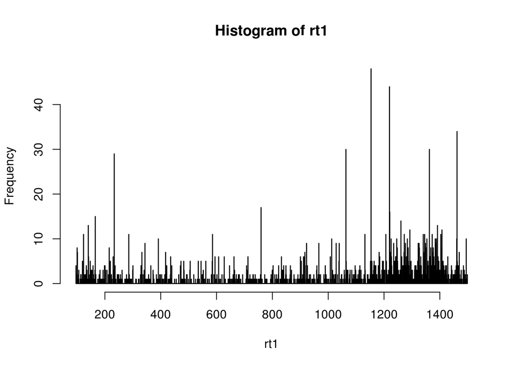

```r
orig_h <- hist(rt1, breaks = bin)
```

Histogram - počet elution order swapping v jednotlivých binech

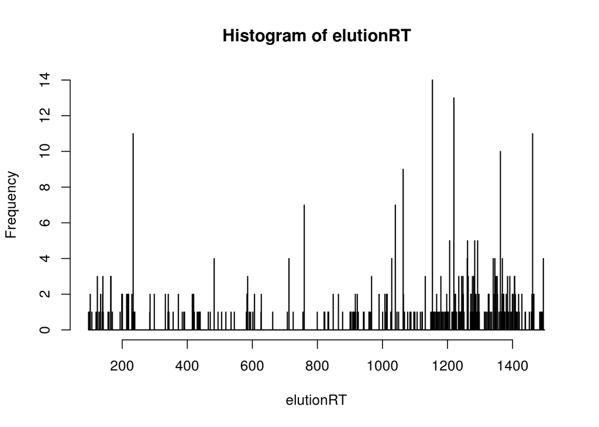

```r
multi_h <- hist(elutionRT, breaks = bin)
```

Jak si můžeme všimnout, jednotlivé hidstogramy jsou si vcelku podobné. Očekávám silnou korelaci mezi počtem peaků v binu a počtem elution order swapping.

```r
cor(orig_h$counts, multi_h$counts)
```

```
## [1] 0.8523414
```

#### Jak je vidět korelace je velmi silná. Lze teda říct, že čím jsou peaky blíž u sebe, tím častěji dochází k elution order swapping (pro bin 1sekunda).

### Bin bude velký 2s

```r
head(bin)
```

```
## [1]  96  98 100 102 104 106
```

Histogram - počet peaků v jednotlivých binech

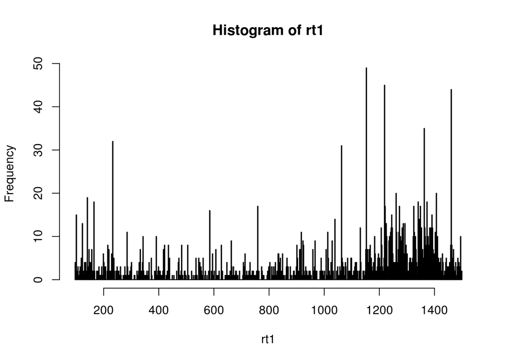

```r
orig_h <- hist(rt1, breaks = bin)
```

Histogram - počet elution order swapping v jednotlivých binech

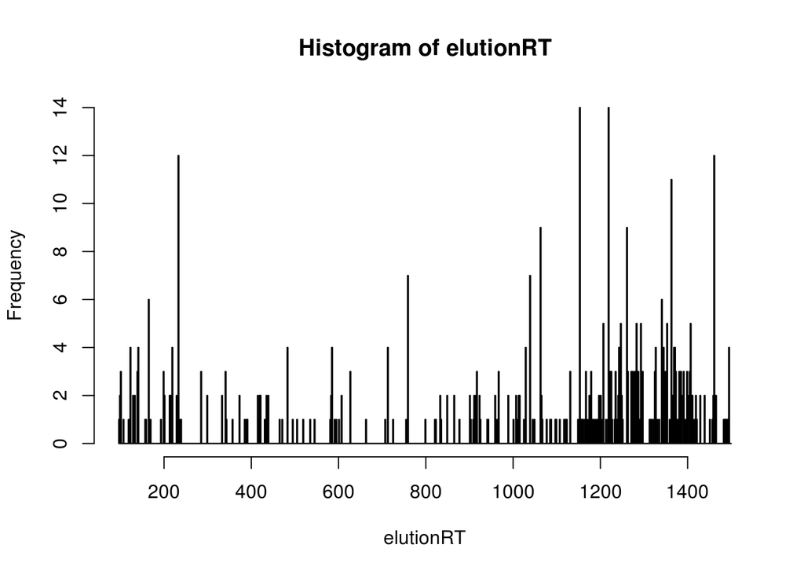

```r
multi_h <- hist(elutionRT, breaks = bin)
```

Jak si můžeme všimnout, jednotlivé hidstogramy jsou si vcelku podobné. Očekávám silnou korelaci mezi počtem peaků v binu a počtem elution order swapping.

```r
cor(orig_h$counts, multi_h$counts)
```

```
## [1] 0.8882313
```

### Vzdálenost mezi peaky

Zde budu zjišťovat vzdálenost na ose RT mezi jednotlivými peaky. Pro konkrétní peak budu hledat dva nejbližší peaky na ose RT a z nich vyberu minimální vzdálenost. Chci totiž najít co nejvíce osamocené peaky, tj. maximalizuji minimální vzdálenost mezi dvěma sousedy. Počítáno pro mzb1.

```r
mzb1_dist <- dist(rt1)
mzb1_dist_matrix <- as.matrix(mzb1_dist)
pointDisc <- rep(0, nrow(mzb1_dist_matrix))
for(i in 2:(nrow(mzb1_dist_matrix)-1))
{
  pointDisc[i] <- min(mzb1_dist_matrix[i,c(i-1, i+1)])
}
pointDisc
```

```
##    [1] 0.00000 0.02032 0.02032 0.18684 0.13057 0.13057 0.11679 0.01970
##    [9] 0.00000 0.00000 0.01969 0.04440 0.00622 0.00622 0.00000 0.00000
##   [17] 0.01957 0.00000 0.00000 0.00000 0.21147 0.54372 0.66850 0.25116
##   [25] 0.04247 0.04247 0.71875 2.18106 0.63015 0.31077 0.24213 0.24213
##   [33] 0.52331 1.00910 0.10892 0.10892 0.11053 0.05405 0.05405 0.29038
##   [41] 0.02010 0.02010 0.52195 0.32520 0.32520 0.25165 0.00000 0.00000
##   [49] 0.00000 0.00000 0.00000 0.00000 0.03588 0.03588 0.03227 0.03227
##   [57] 0.84642 0.16855 0.16855 1.22046 0.25471 0.25471 0.02016 0.02016
##   [65] 0.11582 0.00176 0.00176 0.26012 0.14456 0.00000 0.00000 0.16574
##   [73] 1.24065 0.37330 0.37330 0.24643 0.24643 0.14506 0.00000 0.00000
##   [81] 0.00000 0.00000 0.01011 0.00339 0.00339 0.01349 0.00000 0.00000
##   [89] 0.11559 0.11559 0.14293 0.00000 0.00000 0.00000 0.01012 0.31318
##   [97] 0.31318 0.77977 0.77977 0.22668 0.22668 0.00000 0.00000 0.14511
##  [105] 0.01013 0.01013 0.90711 0.11964 0.11964 0.15478 0.11320 0.11320
##  [113] 0.39664 0.23268 0.14466 0.14466 0.37357 0.64427 0.00000 0.00000
```

[output cut: 271 more lines]

Grafický výstup, osa x je RT a y je minimální vzdálenost mezi dvěma sousedy. Snažíme se tedy najít vhodný práh, kde bychom mohli označit peaky za málo/vysoce pravděpodné, že dojde k elution order swap.

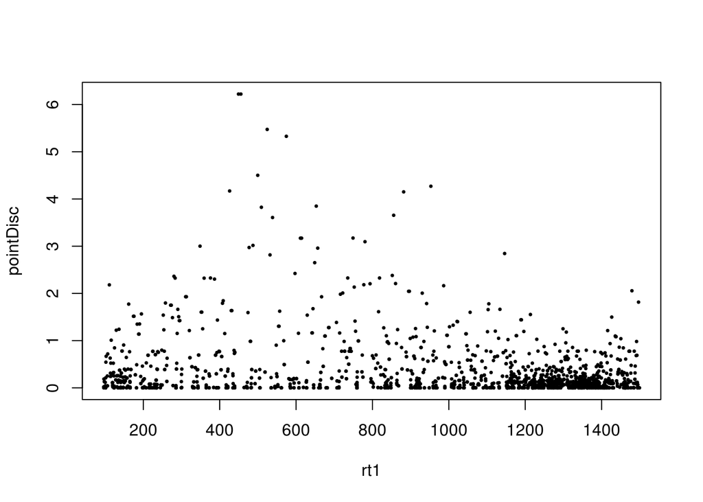

```r
plot(rt1, pointDisc, cex = 0.5, pch=20)
```

Původní histogram

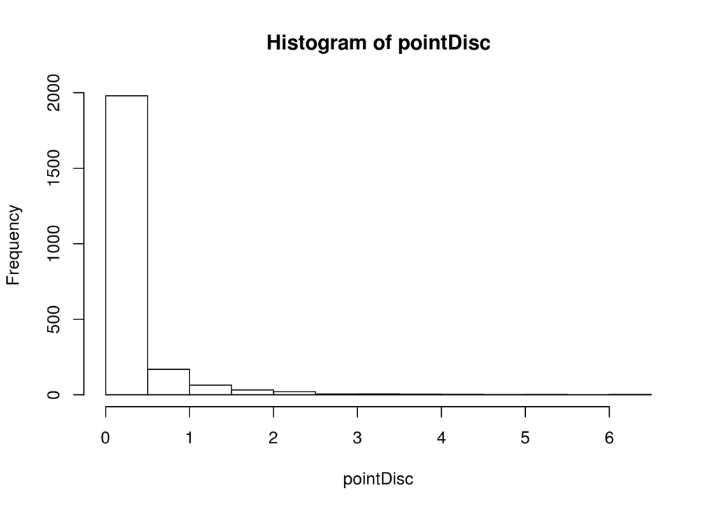

```r
hist(pointDisc)
```

Histofgram se zlogaritmovanými daty

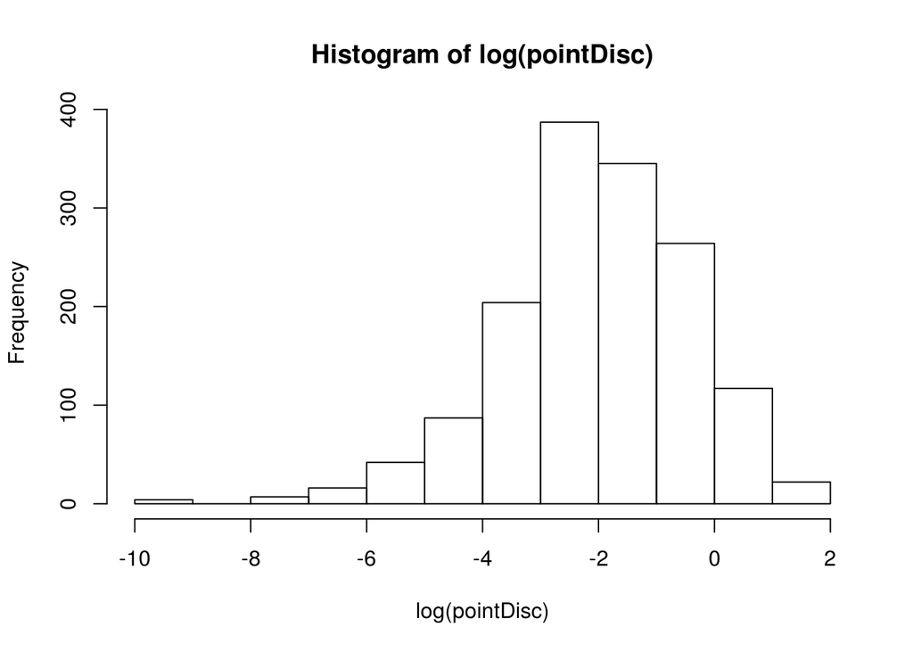

```r
hist(log(pointDisc))
```

Zde není úplně jasné jaké peaky označit za outliery (nepravděpdobné že dojde k EOS). Zajímavá je ale myšlenka, že bychom zohlednili i intezitu, protože předpokládáme, že peak s vyšší intenzitou bude šiřší. Pozn. my teď pracujeme s profilem (jeden bod), předtím ale data určitě vykazovala tvar spíše Gaussovské křivky, proto lze usuzovat, že peak s vyšší intenzitou je “širší” a tím může být i pravděpdobnější překryv s nějakým jiným.